# xwMOOC 자연어 처리 - 텍스트

네이버 뉴스

# 1 네이버 뉴스 [^1]

네이버 검색에 “데이터 사이언스”를 검색어로 넣어 관련 뉴스를 100개 가져오는 뉴스 크롤러를 작성한다. 그리고 나서 `purrr` 팩키지 `map2_df` 함수로 데이터프레임으로 깔끔하게 가져온다.

```r
# 0. 환경설정 -----
library(tidyverse)
library(rvest)
library(glue)

# 1. 데이터 긁어오기 -----
## 네이버 뉴스 함수 작성
get_naver_news <- function(keyword, page){

  url <- glue("https://search.naver.com/search.naver?&where=news&query=",keyword,"&sm=tab_pge&sort=0&photo=0&field=0&reporter_article=&pd=1&ds=2018.02.25&de=2018.03.04&docid=&nso=so:r,p:1w,a:all&mynews=0&cluster_rank=38&start=", page,"&refresh_start=0")

  news_html <- read_html(url, handle = curl::new_handle("useragent" = "Mozilla/5.0"))

  title     <- html_nodes(news_html, xpath='//*[@class="type01"]/li/dl/dt/a') %>% html_text
  source    <- html_nodes(news_html, xpath='//*[@class="type01"]/li/dl/dd[1]/span[1]') %>% html_text
  text      <- html_nodes(news_html, xpath='//*[@class="type01"]/li/dl/dd[2]') %>%  html_text

  news_df <- data.frame(title, source, text)
  return(news_df)
}

page_list <- 1:10
keyword_list <- rep("데이터%20사이언스", 10)

news_df <- map2_df(keyword_list, page_list, get_naver_news)

DT::datatable(news_df)
```

|  | title | source | text |
| --- | --- | --- | --- |
| 1 | 엔코아 김옥기 상무, 와이즈유서 ‘AI시대의 데이터 과학과 대학’ 특강 | 브릿지경제 | 기업들도 데이터 사이언스에 주목하기 시작했다”고 설명했다. 그는 “요즘처럼 저성장 시대에는 유통과 가격 인하 등으로 경쟁하는 것보다 데이터를 활용해 새로운 전략을 수립하는 것이 훨씬 효과적”이라고... |
| 2 | “빅데이터 연구 없이 인공지능 발전 없다” | 서울경제 | 기업들도 데이터 사이언스에 주목하기 시작했다”고 설명했다. 그는 “요즘처럼 저성장 시대에는 유통과 가격 인하 등으로 경쟁하는 것보다 데이터를 활용해 새로운 전략을 수립하는 것이 훨씬 효과적”이라... |
| 3 | KB국민은행-아주대학교, 『빅데이터 및 인공지능 활용을 위한 산학협력 업무협... | 비지니스코리아 | 한편, 수학적 관점의 데이터 분석에 강점이 있는 아주대학교는 아주 산업수학센터, 경영 빅데이터 센터, 데이터 사이언스 학과가 중심이 되어 참여한다. 특히, 정재훈 아주대학교 데이터 사이언스 학과 교수는 2017... |
| 4 | 명지대-강남대 '전공 및 학생부종합전형 위한 교사연수' 개최 | 아시아투데이 | 산업데이터사이언스학부, 유아교육과, 한영문화콘텐츠학과 등을 강조했다. 장영순 명지대 입학처장은 “이번 교사 연수에서 소개되는 다양한 프로그램이 참여 교사의 진로 및 진학지도 역량 강화에 도움이 되길... |
| 5 | "없다면 키우자"…은행권, 디지털 인재 양성 총력전 | ZDNet Korea | MBA과정에서는 데이터사이언스와 비정형빅데이터 분석 등을 배울 수 있다. 신한은행은 4차 산업혁명의 기술로 꼽히는 빅데이터와 관련한 인력을 육성 중이다. 공모를 통해 6개월 과정인 커리어 플러스 스쿨에 참석할 수... |
| 6 | 패스트캠퍼스, 작년 매출 200억 기록..."매년 2배씩 성장" | 한국경제 | 인공지능(AI), 빅데이터, 데이터사이언스 등 최신 정보기술(IT) 관련 교육과정을 빠르게 시장에 선보여 IT업체 개발자들 사이에서 인기를 끌고 있다. 패스트캠퍼스는 매출과 함께 다양한 통계 자료도 공개했다. 가장... |
| 7 | 테고사이언스 칼로덤, 당뇨성족부궤양 치료 효과 입증 | MTN | 실제로 의료현장의 데이터가 축적된 본 논문은 칼로덤®의 RWD(Real World Data)로 활용된다. 테고사이언스는 최근 칼로덤의 급여 확대를 신청한 데 있어 본 논문을 추가 제출했고 이는 심평원이 칼로덤®의 급여 확대... |
| 8 | 카드사, 디지털 전문인력 확충 '속도' | 대한금융신문 | 현대카드 관계자는 "데이터 분석을 기반으로 하는 '데이터 사이언스 컴퍼니'를 지향하고 있어 디지털 전문인력을 충원했으며 전사적 코딩 교육도 진행했다"며 "전체 임직원의 20% 이상을 디지털 전문 인력으로 양성하는... |
| 9 | 넥스트사이언스, 전일 대비 약 6% 상승한 6,260원 | 한국경제TV | [한국경제TV 라이온봇 기자] [그림 1] 최근 3개월 간 주가 추세 및 기간별 수익률 넥스트사이언스는 1월 10일... (위의 AI인공지능 점수는 재무 데이터를 기반으로 전체 상장 종목과 비교/분석하여 도출한 점수로 높은... |
| 10 | [CES 2019] IBM, AI·양자컴퓨팅 기술력 과시 | ZDNet Korea | 소프트웨어 엔지니어링, 사이버 보안, 데이터 사이언스와 데이터 분석 등 급성장 중인 IT분야에서 실무에 사용될 수 있는 교육 과정을 지원한다. IBM은 향후 5년간 매년 450개 이상의 교육 과정을 마련할 예정이다.... |

[output cut: 90 more lines]

# 2 뉴스 텍스트 전처리

## 2.1 형태소 분석 [^2] [^3]

자바 기반 [`KoNLP` 팩키지]는 2016-12-15일 이후 업데이트가 2년 넘게 진행이 되고 있지 않고 있으며 `KoSpacing` 팩키지도 딥러닝 기반으로 개발은 되었으나 원할히 사용하기 까지 다수 복잡한 과정을 거쳐야 되고 개발된지 얼마되지 않아 활용사례가 극히 제한적이다.

NLP4kec는 한글은 은전한닢 형태소 분석기를 사용하고, 영어, 중국어는 Stanford core NLP 사용하여 한글, 영어, 중국어 텍스트 데이터 파일을 입력받아 형태소 분석 후 R tm package에서 사용할 수 있도록 해주는 팩키지로 개발되어 [Kevin Seongho Na](https://mrkevinna.github.io/)를 비롯하여 사용자층을 넓혀가고 있다.

```r
library(NLP4kec)

news_df$bow <- r_parser_r(news_df$text, language = "ko", useEn = TRUE)

news_tidy_df <- news_df %>%
  mutate(bow = map(bow, str_split, pattern=" ") ) %>%
  select(title, source, bow) %>%
  unnest(bow) %>%
  unnest(bow)

news_tidy_df %>% head
```

```
                                                                title
1 엔코아 김옥기 상무, 와이즈유서 ‘AI시대의 데이터 과학과 대학’ 특강
2 엔코아 김옥기 상무, 와이즈유서 ‘AI시대의 데이터 과학과 대학’ 특강
3 엔코아 김옥기 상무, 와이즈유서 ‘AI시대의 데이터 과학과 대학’ 특강
4 엔코아 김옥기 상무, 와이즈유서 ‘AI시대의 데이터 과학과 대학’ 특강
5 엔코아 김옥기 상무, 와이즈유서 ‘AI시대의 데이터 과학과 대학’ 특강
6 엔코아 김옥기 상무, 와이즈유서 ‘AI시대의 데이터 과학과 대학’ 특강
      source      bow
1 브릿지경제     기업
2 브릿지경제   데이터
3 브릿지경제 사이언스
4 브릿지경제     주목
5 브릿지경제     시작
6 브릿지경제     설명
```

# 3 탐색적 데이터 분석

`news_df`에서 관련도순으로 상위 100개 기사를 추출하였다. “데이터 사이언스” 용어와 관련된 기사를 가장 많이 출고한 언론사 두곳을 찾아 비교분석해 보자.

## 3.1 `tidy` 방식 아님

전통적인 방식으로 `quanteda` 팩키지를 동원해서 데이터 사이언스 관련 출고 기사가 많은 두 언론사(“한국경제TV”, “ZDNet Korea”)를 추출하여 `dfm()` 행렬을 만들어 빈도수를 계산하고 이를 `ggplot`에 넣어 각각 시각화 산출물을 만들고 `cowplot`으로 시각화하는 코드는 다음과 같다.

```r
library(quanteda)
library(extrafont)
loadfonts()

## 상위 언론사 추출
news_df %>%
  count(source, sort = TRUE)
```

```
# A tibble: 19 x 2
   source             n
   <chr>          <int>
 1 한국경제TV        18
 2 ZDNet Korea       11
 3 이슈메이커         9
 4 MTN                8
 5 중앙일보           8
 6 대학저널           7
 7 대한금융신문       6
 8 파퓰러사이언스     6
 9 기자협회보         5
10 디지털데일리       4
11 플래텀             4
12 노컷뉴스           3
13 비지니스코리아     3
14 서울경제           2
15 아이티비즈         2
16 브릿지경제         1
17 아시아투데이       1
18 조선비즈           1
19 한국경제           1
```

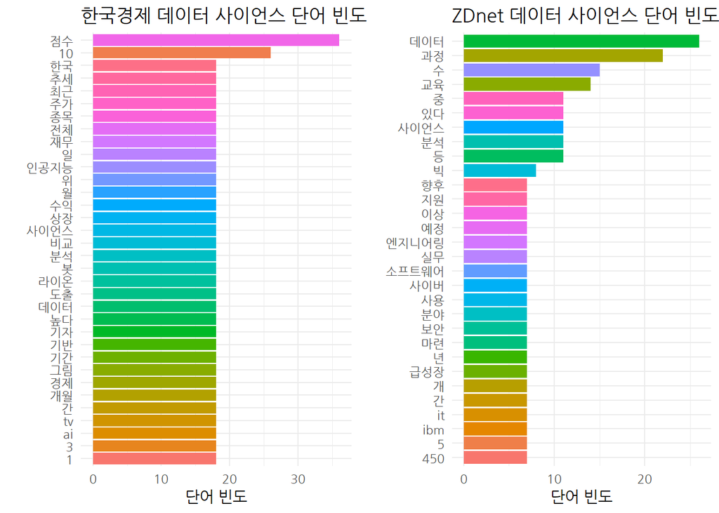

```r
ds_eda_df <- news_tidy_df %>%
  filter(source %in% c("한국경제TV", "ZDNet Korea"))

ds_ke_df <- ds_eda_df %>% filter(source == "한국경제TV")
ds_ke_m <- dfm(ds_ke_df$bow) %>% as.matrix

ds_zdnet_df <- ds_eda_df %>% filter(source == "ZDNet Korea")
ds_zdnet_m <- dfm(ds_zdnet_df$bow) %>% as.matrix

ds_ke_freq   <- colSums(ds_ke_m)
ds_zdnet_freq <- colSums(ds_zdnet_m)

ke_g <- ds_ke_freq %>%
    as.data.frame() %>%
    rownames_to_column(var="word") %>%
    rename(frequency = '.') %>%
    arrange(desc(frequency)) %>%
    top_n(15, frequency) %>%
    ggplot(aes(x=fct_reorder(word, frequency), y=frequency, fill=word)) +
      geom_col() +
      coord_flip() +
      labs(x="", y="단어 빈도", title="한국경제 데이터 사이언스 단어 빈도") +
      theme_minimal(base_family = "NanumGothic") +
      theme(legend.position = "none")

zdnet_g <- ds_zdnet_freq %>%
    as.data.frame() %>%
    rownames_to_column(var="word") %>%
    rename(frequency = '.') %>%
    arrange(desc(frequency)) %>%
    top_n(15, frequency) %>%
    ggplot(aes(x=fct_reorder(word, frequency), y=frequency, fill=word)) +
      geom_col() +
      coord_flip() +
      labs(x="", y="단어 빈도", title="ZDnet 데이터 사이언스 단어 빈도") +
      theme_minimal(base_family = "NanumGothic") +
      theme(legend.position = "none")

cowplot::plot_grid(ke_g, zdnet_g)
```

## 3.2 `tidy` 방식

`tidy` 방식으로 코드를 작성하게 되면 `dplyr` 동사를 사용해서 각 언론사별로 15개 단어를 추출하여 시각화를 한다. 이번 경우 단어길이가 1인 것은 제외시킨다. 그리고 나서 `ggplot`으로 시각화한다.

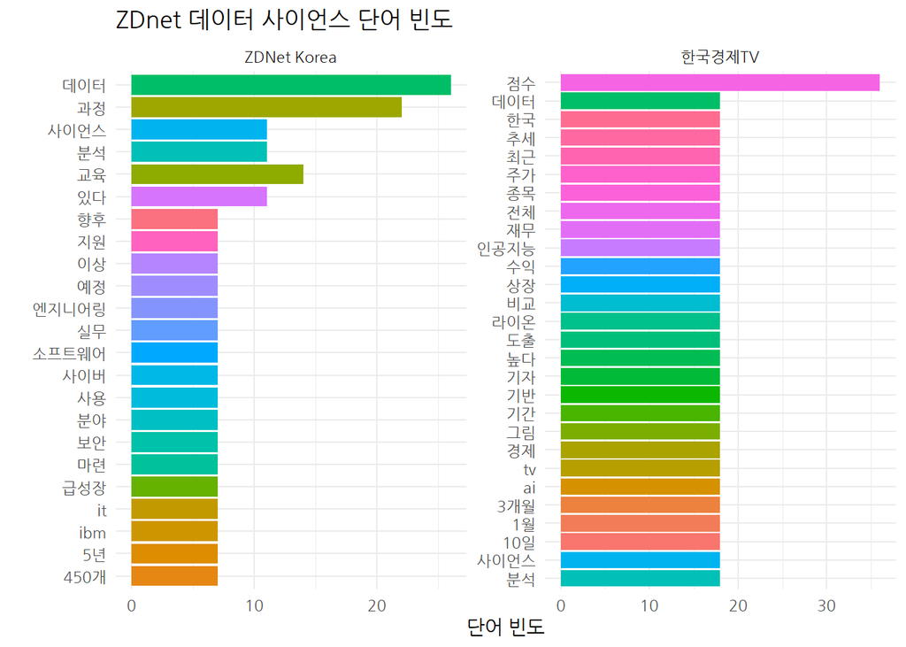

```r
news_tidy_df %>%
  count(source, bow, sort=TRUE) %>%
  mutate(word_length = str_length(bow)) %>%
  filter(word_length > 1) %>%
  filter(source %in% c("한국경제TV", "ZDNet Korea"))   %>%
  group_by(source) %>%
  top_n(15, wt=n) %>%
  ungroup() %>%
  ggplot(aes(x=fct_reorder(bow,n), y=n, fill=bow)) +
    geom_col() +
    facet_wrap(~source, scales = "free") +
    coord_flip() +
    labs(x="", y="단어 빈도", title="ZDnet 데이터 사이언스 단어 빈도") +
    theme_minimal(base_family = "NanumGothic") +
    theme(legend.position = "none")
```

[^1]: [Jinseog Kim(2018), “웹에서 텍스트 자료의 수집”,Dongguk University](http://datamining.dongguk.ac.kr/lecture_select.php?lid=201813&y=2018&s=1)
[^2]: [KoSpacing, “한글 띄어쓰기 패키지를 사용해보자”](https://mrchypark.github.io/post/kospacing-한글-띄어쓰기-패키지를-사용해보자/)
[^3]: [package install error on windows #3](https://github.com/haven-jeon/KoSpacing/issues/3)